# Probabilistic marketing models

kumar S Das

February 20, 2018

### Question-1

#### Q1(a)

What do each of the models predict will be the penetration of coffee creamer purchases after 1period? What about after 5 periods? 26 periods?

```r
r_nbd <- 0.181
a_nbd <- 0.059
r_hcnb <- 1.226
a_hcnb <- 0.215
p_hcnb <- 0.551

reach_nbd <- function(r,a,T){
  return(1-(a/(a+T))**r)
}

reach_hcnb <- function(r,a,p,T){
  return(1-(p+(1-p)*((a/(a+T))**r)))
}

T <- c(1,5,26)
nbd=reach_nbd(r_nbd,a_nbd,T)
hcnb=reach_hcnb(r_hcnb,a_hcnb,p_hcnb,T)
reach <- cbind(T,nbd,hcnb)
reach <- as.data.frame(reach)
names(reach) <- c("Week","NBD Reach","HCNB Reach")
reach
```

```
##   Week NBD Reach HCNB Reach
## 1    1    0.4071     0.3953
## 2    5    0.5532     0.4400
## 3   26    0.6679     0.4478
```

#### Q1(b)

If you were the product manager for this particular brand of coffee creamer, and your manager asked you to estimate the maximum penetration that you could expect from this product, what one answer would you give? How would you justify the answer?

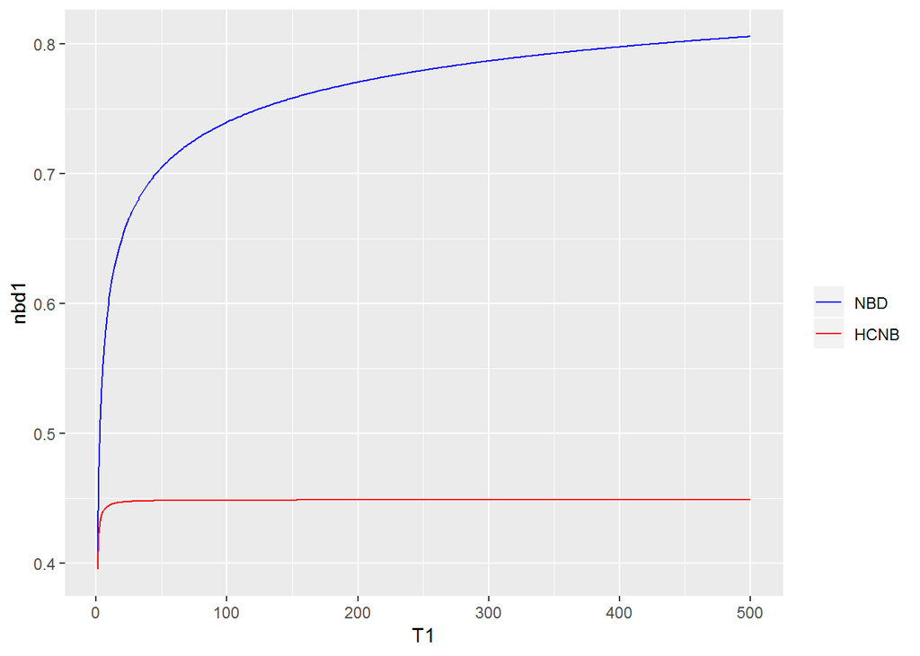

```r
T1 <- seq(1:500)
nbd1=reach_nbd(r_nbd,a_nbd,T1)
hcnb1=reach_hcnb(r_hcnb,a_hcnb,p_hcnb,T1)
reach1 <- cbind(T1,nbd1,hcnb1)
reach1 <- as.data.frame(reach1)

ggplot(data=reach1) +
  geom_line(aes(x=T1, y=nbd1,col='NBD'))+
  geom_line(aes(x=T1, y=hcnb1,col='HCNB'))+
  scale_colour_manual("",
                      breaks = c("NBD", "HCNB"),
                      values = c("red","blue"))
```

The maximum penetration that we could expect from this product is: 0.449.

```r
1-p_hcnb
```

```
## [1] 0.449
```

Considering the NBD model we will achieve a maximum reach of 1 if we wait out long enough. However considering the HCNB model, we can only achieve a maximum reach of 0.449. This is because in HCNB model we target those customers who are ever triers. Even though we can reach out to more customers using NBD model, it can be observed from the plot that the NBD curve approaches the asymptote(1) very slowly, whereas the HCNB rach curve approache its asyptote (0.449) at much faster rate, implying that we can reach out to the ever triers faster.

### Q2 -Ace snackfoods

Ace Snackfoods, the maker of Krunchy Bits, conducted a trial launch in Tulsa. They monitored purchases of 1,300 panelists for 52 total weeks. The file KB_Tulsa.txt contains the ID number of each panelist, the Market (Tulsa for everyone), and the week of the purchase.

#### Q2(a)

Divide the sample into a 20-week “calibration” set, and a 32-week “holdout” set. Estimate and describe the distribution of purchase rates using only the calibration data.

We tested three models to fit the calibration period data. Shown below are the ENT, EG and NBD models. We chose NBD model to fit the holdout data

**ENT model**

```r
#log of probability of customers for t<=T
log_p_exp <-function(l,t){
  return(log(exp(-l*(t-1))-exp(-l*t)))
}

#log of probability of customers for t>T
log_p_exp1 <- function(l,T){
  return(log(1-exp(-l*T)))
}

# Log likelihood for ENT model
ll_ent <- function(pars,d,Ntot){
  l <- exp(pars[1])
  p <- invlogit(pars[2])
  t <- d$Week# vector of weeks
  W <- length(t) #total no. of weeks
  T <- t[W]
  N <- d$incrHH
  Nsurv <- Ntot-sum(N)
  t1 <- p*exp(log_p_exp(l,t))
  t2 <- (1-p)+p*(1-exp(log_p_exp1(l,T)))
  t3 <- N*log(t1) #log likelihood of customers who purhcased
  t4 <- Nsurv*log(t2) #log likelihood of surviving customers
  ll_tot <- sum(t3)+t4 #total log likelihood
  return(-ll_tot)
}

# Parameters estimates of ENT model

Ntot <- 1300 #total no. of customers
opt_ent <- optim(c(0,0), fn=ll_ent, d=training_set, Ntot=1300)
params <- opt_ent$par
l_ent <- exp(params[1])
p_ent <- invlogit(params[2])

# Collecting the results into a dataframe
d2 <- data.frame(matrix(NA, nrow=length(d1$Week),ncol=5))
names(d2) <- c(names(d1), 'pred_incrHH', 'pred_cumHH')
d2[,1:3] <- d1
d2 <- d2 %>% mutate(pred_incrHH=Ntot*p_ent*exp(log_p_exp(l_ent,Week)),
                    pred_cumHH=cumsum(pred_incrHH)) %>%
  mutate(pred_incrHH=round(pred_incrHH,0),
         pred_cumHH=round(pred_cumHH,0))
```

The parameter estimates of ENT model are:

```r
l_ent
```

```
## [1] 0.1277
```

```r
p_ent
```

```
## [1] 0.133
```

**EG model**

```r
# log probability of EG
log_p_eg <- function(a,r,t){
  t1 <- 1-(a/(a+t))^r
  t2 <- 1-(a/(a+(t-1)))^r
  return(log(t1-t2))
}

# Log likelihood for EG model
ll_eg <- function(pars,d,Ntot){
  a <- exp(pars[1]) #converts output from (-inf,inf) to (0,inf)
  r <- exp(pars[2])
  t <- d$Week# vector of weeks
  W <- length(t) #total no. of weeks
  T <- t[W]
  N <- d$incrHH
  Nsurv <- Ntot-sum(N)
  t41 <- log_p_eg(a,r,t)
  t42 <- 1-sum(exp(t41))
  t43 <- N*(t41)
  t44 <- Nsurv*log(t42)
  ll_tot <- sum(t43)+t44
  return(-ll_tot)
}

# Parameters estimates of EG model
Ntot <- 1300
opt_eg <- optim(c(0,0), fn=ll_eg, d=training_set, Ntot=Ntot)
params <- opt_eg$par
a_eg <- exp(params[1])
r_eg <- exp(params[2])
ll_eg <- -opt_eg$value

# Collecting the results into a dataframe
d3 <- d2
d3[, c('pred_incrHH_EG', 'pred_cumHH_EG')] <- NA
d3 <- d3 %>%
  mutate(pred_incrHH_EG=Ntot*exp(log_p_eg(a_eg,r_eg,Week)),
         pred_cumHH_EG=cumsum(pred_incrHH_EG)) %>%
  mutate(pred_incrHH_EG=round(pred_incrHH_EG,0),
         pred_cumHH_EG=round(pred_cumHH_EG,0))
```

The paremeter estimates of EG model are

```r
a_eg
```

```
## [1] 2.671
```

```r
r_eg
```

```
## [1] 0.06244
```

**NBD model**

```r
Tulsa <- read.table("KB_Tulsa.txt", header = T)
calib <- Tulsa[Tulsa$Week <= 20,]
holdout <- Tulsa[Tulsa$Week >20,]

calib <- calib %>%
  dplyr::group_by(ID) %>%
  dplyr::select(ID) %>%
  dplyr::summarise(x=n())%>%
  dplyr::select(x) %>%
  dplyr::group_by(x) %>%
  dplyr::summarise(n=n())

calib <- rbind(c(0,1300-sum(calib$n)),calib)

log_nbd <- function(r,alpha,x,T) {
  lgamma(r+x)-lgamma(r)-lfactorial(x)+r*(log(alpha)-log(alpha+T))+x*(log(T)-log(alpha+T))
}

LLfunc <- function(pars,x,n,T) {
  r <- exp(pars[1])
  alpha <- exp(pars[2])

  LL_all <- sum(n*log_nbd(r,alpha,x,T))
  return(-LL_all)
}

start <- c(0,0)
opt <- optim(start, LLfunc,x=calib$x,n=calib$n, T=20)
r <- exp(opt$par[1])
alpha <- exp(opt$par[2])
LL <- -opt$value
```

The parameters estimates of NBD model are:

```r
cat("BG parameters: r = ",r,", alpha = ",alpha,". LL = ",LL,"\n")
```

```
## BG parameters: r =  0.1034 , alpha =  7.883 . LL =  -712.2
```

#### Q2(b)

Using the parameter estimates from the calibration set, compare the predicted counts for both the calibration and holdout periods. That is, using the parameters estimated from the first 20 weeks of data, predict for those same 20 weeks, and forecast for the next 32 weeks. Compare the predictions/forecasts with the observed data, and assess the model performance. Explain why the models perform as well as, or as poorly as, they do

Shown below are the plots for the three models,showing how they fit the calibration and holdout period data.

Plots for the **NBD model**

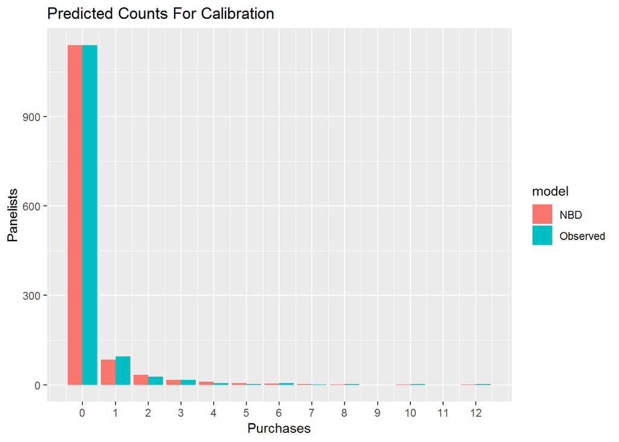

```r
N <- 1300

calib_pred <- calib %>%
  mutate(prob=exp(log_nbd(r,alpha,calib$x,20))) %>%
  mutate(pred=N*prob)

holdout <- holdout %>%
  dplyr::select(ID) %>%
  dplyr::group_by(ID) %>%
  dplyr::summarise(x=n())%>%
  dplyr::select(x) %>%
  dplyr::group_by(x) %>%
  dplyr::summarise(n=n())
holdout <- rbind(c(0,1300-sum(holdout$n)),holdout)

holdout_pred = holdout %>%
  mutate(prob=exp(log_nbd(r,alpha,holdout$x,32))) %>%
  mutate(pred=N*prob)

pcalib <- calib_pred %>%
  dplyr::select(x,Observed = n,NBD=pred) %>%
  tidyr::gather(model,value,-x)

phold <- holdout_pred %>%
  dplyr::select(x,Observed=n, NBD=pred) %>%
  tidyr::gather(model,value,-x)

(calib_plot <- pcalib %>%
                ggplot(aes(x = x, y = value, fill = model)) %>%
                + geom_bar(stat='identity', position='dodge') %>%
                + scale_x_continuous("Purchases", breaks = 0:12) %>%
                + scale_y_continuous("Panelists") %>%
                + ggtitle("Predicted Counts For Calibration"))
```

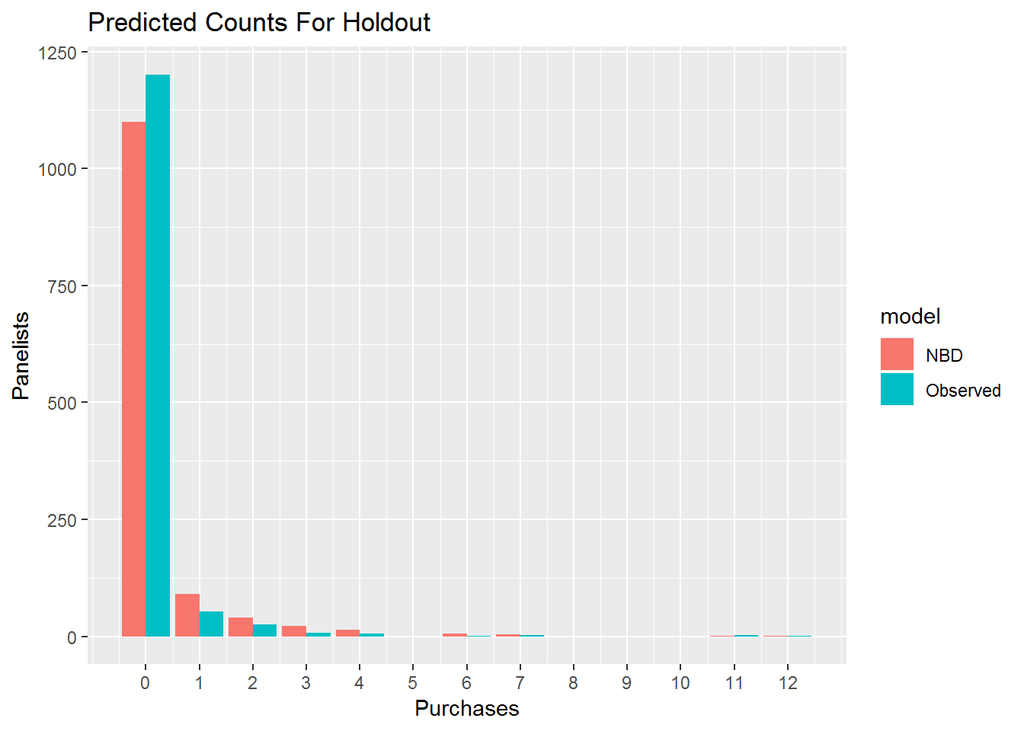

```r
(hold_plot <- phold %>%
                ggplot(aes(x = x, y = value, fill = model)) %>%
                + geom_bar(stat='identity', position='dodge') %>%
                + scale_x_continuous("Purchases", breaks = 0:12) %>%
                + scale_y_continuous("Panelists") %>%
                + ggtitle("Predicted Counts For Holdout"))
```

Plots comparing the ** ENT and EG models** versus the actual data

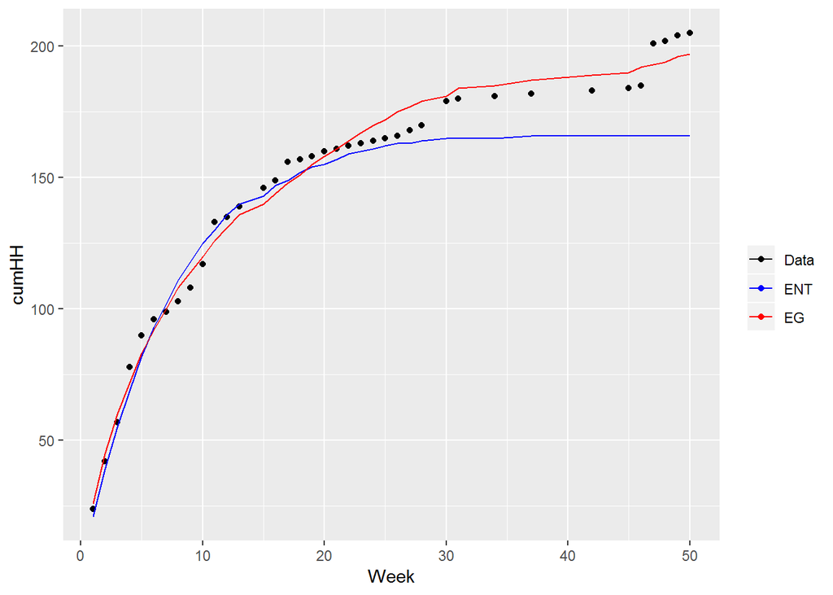

```r
# Plots to comapre model prediction
ggplot(data=d3)+
  geom_point(aes(x=Week, y=cumHH, col='Data'))+
  geom_line(aes(x=Week, y=pred_cumHH, col='ENT'))+
  geom_line(aes(x=Week, y=pred_cumHH_EG, col='EG'))+
  scale_colour_manual("",
                      breaks = c("Data", "ENT", "EG"),
                      values = c("black","red","blue"))
```

#### Q2(c)

Using the same model that you used in part 2a, estimate and describe the distribution of purchase rates using only the data in the holdout sample. Compare and contrast the estimated distribution with the one from part 2a.

We decided to chose the NBD model. So we estimate the fit again using only the holdout period data

```r
start <- c(0,0)
opt <- optim(start, LLfunc,x=holdout$x,n=holdout$n, T=32)
r <- exp(opt$par[1])
alpha <- exp(opt$par[2])
LL <- -opt$value
par_pred_hold <- c(r,alpha,LL)
```

The parameters predicted using the NBD model for holdout preiod are:

```r
cat("BG parameters: r = ",r,", alpha = ",alpha,". LL = ",LL,"\n")
```

```
## BG parameters: r =  0.06127 , alpha =  12.14 . LL =  -491.5
```

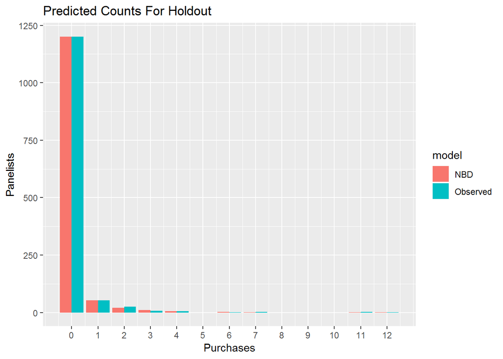

```r
hold_pred2 = holdout %>%
  mutate(prob=exp(log_nbd(r,alpha,holdout$x,32))) %>%
  mutate(pred=N*prob)

phold2 <- hold_pred2 %>%
  dplyr::select(x,Observed=n, NBD=pred) %>%
  tidyr::gather(model,value,-x)

(hold_plot2 <- phold2 %>%
                ggplot(aes(x = x, y = value, fill = model)) %>%
                + geom_bar(stat='identity', position='dodge') %>%
                + scale_x_continuous("Purchases", breaks = 0:12) %>%
                + scale_y_continuous("Panelists") %>%
                + ggtitle("Predicted Counts For Holdout"))
```

A comparison of the parameters estimated for the calibration and holdout data using the NBD model:

```r
#parameter estimates using calibration data
opt1 <- optim(start, LLfunc,x=calib$x,n=calib$n, T=20)
r1 <- exp(opt1$par[1])
alpha1 <- exp(opt1$par[2])
LL1 <- -opt1$value
par_pred_calib <- c(r1,alpha1,LL1)

#parameter estimates using holdout data
opt <- optim(start, LLfunc,x=holdout$x,n=holdout$n, T=32)
r <- exp(opt$par[1])
alpha <- exp(opt$par[2])
LL <- -opt$value
par_pred_hold <- c(r,alpha,LL)
as.data.frame(cbind(par_pred_calib,par_pred_hold),row.names = c("r","alpha","log likelihood"))
```

```
##                par_pred_calib par_pred_hold
## r                      0.1034       0.06127
## alpha                  7.8826      12.13773
## log likelihood      -712.2371    -491.53970
```

#### Q2(d)

Given your answers to the preceding parts, give an overall, intuitive explanation of differences between the calibration and holdout periods. How might you refine your model to account for the differences?

### Q3

I estimated the exponential-gamma model using all 52 weeks of the Krunchy Bits data, and got estimates r=0.045, alpha=6.764

#### Q3(a)

Using these parameter estimates, what is the probability that a randomly chosen person makes his or her initial purchase within the first year (by the end of week 52)?

```r
r = 0.045; alpha=6.764
eg <- function(r,alpha,t) {
  1-(alpha/(alpha+t))^r
}
p52 <- eg(r,alpha,52)
# the prob that a randomly chosen person amkes pruchase in the first 52 weeks si same as the reach
p52
```

```
## [1] 0.0927
```

#### Q3(b)

What is the probability that someone who has not yet purchased Krunchy Bits by the end of the first year would make his initial purchase by the end of year 2 (week 104)?

```r
prob_nt <- 1-p52
prob_ba <- eg(r,alpha,104)-p52

prob_ba/prob_nt
```

```
## [1] 0.02812
```

#### Q3(c)

Are your answers to parts 3a and 3b the same, or different? Give an intuitive explanation of why

Ans: 3(b) is conditional on the first year purchase, the prob of buying is lower if the person does not buy at the first year.The probability of making a pruchase goes down as time increases. More customers are likely to buy when the product is laucnhed. As time increases the impact of the product launch decreases without the aid of any marketing. So it can be expected that the probabilty of pruchase would also go down.

#### Q3(d)

Suppose I estimated a Weibull-gamma model instead. How do you think your answer to part 3b might change in the presence of positive (c > 1) or negative (c < 1)duration dependence. You may assume that the estimates do not change.

Ans: A positive duration dependence implies that the customer will make a pruchase soon than when we don’t consider any duration dependence (i.e., c = 1). In that case the time to first purhcase would decrease as the factor c has an accelerating effect on time. This means lamda goes up. The expected number of purchases in the same time period increases. On the contrary, when c < 1, it has a dilating effect on time, delaying time to first purhcase. This implies that the mean expected purchase is less compared to the case when c =1;

#### Q3(e)

```r
lamda <- 0.066
p<- 0.085
t3<-24

F <- function(lamda,t3){
 1-exp(-lamda*t3)
}

#under the condition of not yet purchase by week 24
probability <- (1-p)/(1-p +p*(1-F(lamda,t3)))
probability
```

```
## [1] 0.9813
```

#### Q3(f)

```r
p3 <- 0.086
r3 <- 77624
a3 <-1185146
lambda3 <- r3/a3
lambda3
```

```
## [1] 0.0655
```